# KDD_CUP_2009_FINAL_PROJECT

Liping Yao, Jatin Gongiwala, Xia Liu, Kamrun Sumi, Xiaoxu Zhang

12/4/2018

KDD CUP 2009: The KDD Cup 2009 offers the opportunity to work on large marketing databases from the French Telecom company Orange to predict the propensity of customers to switch provider (churn), buy new products or services (appetency), or buy upgrades or add-ons proposed to them to make the sale more profitable (up-selling). Among them, here we are going to handle only churn in this section as a target feature.

## The Goal:

The goal is twofold (a) data cleaning and (b) reduce prediction error rate by using different models.

### DATA CLEANING:

Step-1. Data importation

```r
# You need to change it to a relevant folder on your computer containing the Orange data
#setwd("/Users/manha/Desktop/final project/orange")
# Set randomizer's seed
setwd("/Users/zhangxiaoxu/Desktop")
set.seed(1)
# Common missing data (NA-Not available) data format:
na_strings <- c(
  '',
  'na', 'n.a', 'n.a.',
  'nan', 'n.a.n', 'n.a.n.',
  'NA', 'N.A', 'N.A.',
  'NaN', 'N.a.N', 'N.a.N.',
  'NAN', 'N.A.N', 'N.A.N.',
  'nil', 'Nil', 'NIL',
  'null', 'Null', 'NULL')
#Import data
churn.train<-read.table('orange_small_train.data',sep='\t',header=TRUE,stringsAsFactors=TRUE, na.strings=na_strings)
churn <- read.table("orange_small_train_churn.labels.txt", header = F, sep = '\t') # Response data set
churn.train$churn <- ifelse(churn$V1 == 1, 1, 0)  # Transform target data into binary variabel
```

The KDD Cup data set consists of 50,000 samples and 230 anonnymous features that can be used to predict the outcome of interest churn.

Step-2. Let’s split the data into a training and test data set based on the quantile:

```r
set.seed(2018)
n<-nrow(churn.train)
test<-rnorm(n)>quantile(rnorm(n),0.6)
train<-churn.train[!test,]
test<-churn.train[test,]
all<-rbind(train,test) ## combine both test and train data. we will use it in the future
INR <- 1:29955 # The elements in the rows from 1 to 29955 consist of training data
INS <- 29956:50000 # The elements in the rows from 29956 to 50000 consist of test data
```

Step-3.Check missing value in our data set and plot the histogram.

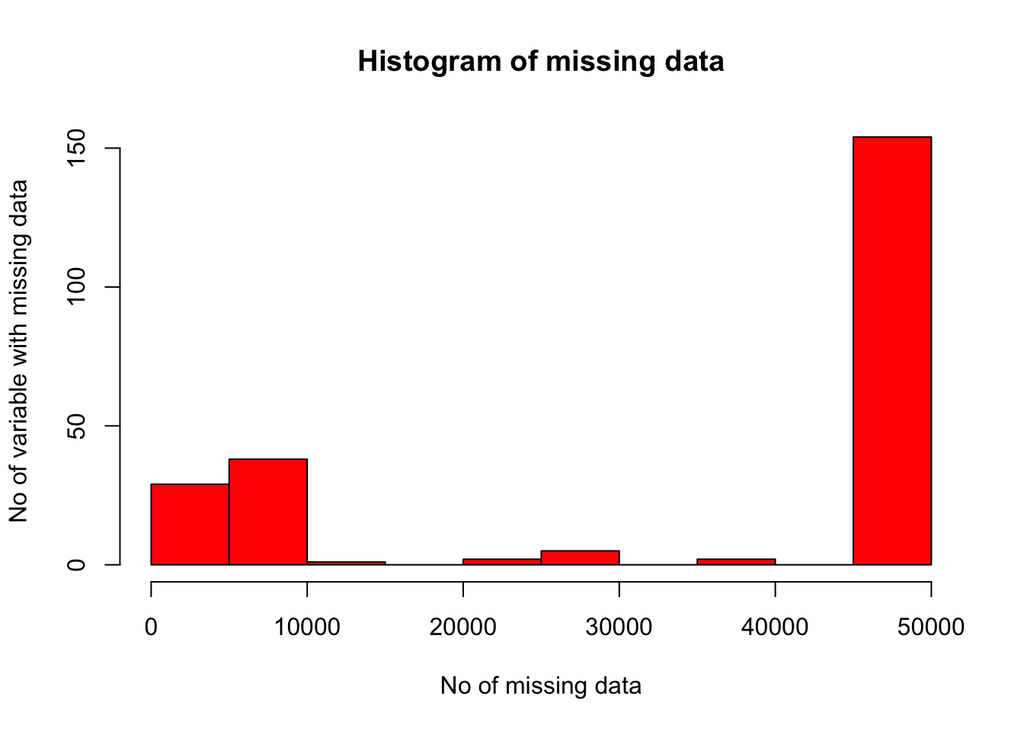

```r
res<-sapply(all,function(x) sum(is.na(x))) # Check the total no of missing data in all the data set
missing<-sort(res,decreasing = TRUE) # sort data in descending order
hist(missing, col= "red", xlab ="No of missing data", ylab = "No of variable with missing data", main="Histogram of missing data" )
```

Step-4: Getting Rid of variable which has too Many Missing Values:

```r
#missing[missing>0]
#summary(all[,names(missing)[missing>0]])
drop<-names(all)%in%names(missing[missing>20000]) # Find the features which has more than 20k missing values
D<-all[!drop] # Keep the data which has less than 20k missing values
res<-sapply(D,function(x) sum(is.na(x)))  # Find out total missing values in the current data set
#str(D)
data.type<-sapply(D, class) # Find the class of the existing data set
table(data.type)
```

```
## data.type
##  factor integer numeric
##      28      35       5
```

Now, we have 68 explanatory variables left. From them, 28 are factorials, 35 are integers, and rest of them are (5) numeric.

STEP-4: Change integer and numarical variables with fewer than 10 unique values to factor variables:

```r
classD<-factor(sapply(D, class))
numvar<-names(D)[data.type != 'factor'] # Find the variables which are not factorial, i.e. numerical
numvar
```

```
##  [1] "Var6"   "Var7"   "Var13"  "Var21"  "Var22"  "Var24"  "Var25"
##  [8] "Var28"  "Var35"  "Var38"  "Var44"  "Var57"  "Var65"  "Var73"
## [15] "Var74"  "Var76"  "Var78"  "Var81"  "Var83"  "Var85"  "Var109"
## [22] "Var112" "Var113" "Var119" "Var123" "Var125" "Var126" "Var132"
## [29] "Var133" "Var134" "Var140" "Var143" "Var144" "Var149" "Var153"
## [36] "Var160" "Var163" "Var173" "Var181" "churn"
```

```r
pdf("hist_numeric_vars.pdf")
for (var_name in numvar){
  hist(D[,var_name], xlab = var_name, main="Histogram of sample data")
}
dev.off()
```

```r
(a <- sapply(D[,numvar], function(x){length(unique(x))})) # Find the max no of unique no in each numerical variables
```

```
##   Var6   Var7  Var13  Var21  Var22  Var24  Var25  Var28  Var35  Var38
##   1487      9   2635    735    736     94    272   4168     14  30833
##  Var44  Var57  Var65  Var73  Var74  Var76  Var78  Var81  Var83  Var85
##      9  25614     16    131    372  29744     14  43043    196    150
## Var109 Var112 Var113 Var119 Var123 Var125 Var126 Var132 Var133 Var134
##    210    231  48511   1488    299  10506     52     20  37604  33182
## Var140 Var143 Var144 Var149 Var153 Var160 Var163 Var173 Var181  churn
##   2649      5     11  18653  36398    403  22958      5      8      2
```

```r
(integer_to_factor_vars <- names(a[which(a<=10)])) #Find out the numerical variables which have less than unique no
```

```
## [1] "Var7"   "Var44"  "Var143" "Var173" "Var181" "churn"
```

```r
D[,integer_to_factor_vars] <- data.frame(apply(D[,integer_to_factor_vars], 2, as.factor)) # Convert numerical variables into factorial which have less than 10 unique values
sapply(D[,numvar], class)
```

```
##      Var6      Var7     Var13     Var21     Var22     Var24     Var25
## "integer"  "factor" "integer" "integer" "integer" "integer" "integer"
##     Var28     Var35     Var38     Var44     Var57     Var65     Var73
## "numeric" "integer" "integer"  "factor" "numeric" "integer" "integer"
##     Var74     Var76     Var78     Var81     Var83     Var85    Var109
## "integer" "integer" "integer" "numeric" "integer" "integer" "integer"
##    Var112    Var113    Var119    Var123    Var125    Var126    Var132
## "integer" "numeric" "integer" "integer" "integer" "integer" "integer"
##    Var133    Var134    Var140    Var143    Var144    Var149    Var153
## "integer" "integer" "integer"  "factor" "integer" "integer" "integer"
##    Var160    Var163    Var173    Var181     churn
## "integer" "integer"  "factor"  "factor"  "factor"
```

```r
data.type<-sapply(D, class)
table(data.type)
```

```
## data.type
##  factor integer numeric
##      34      30       4
```

Now, we have 34 Factorial variables, 30 integer variables and 4 numeric variables.

Step-5: Clean Categorical Variables

Below are categorical features and their number of categories:

```r
#catergorical missing value
factor_var<- names(D)[classD == 'factor'] # Find out the categorical variable names only from the existing data set
(factor_levels <- sapply(D[,factor_var], nlevels)) # Find out how many levels exist in each factorial variables
```

```
## Var192 Var193 Var195 Var196 Var197 Var198 Var199 Var202 Var203 Var204
##    361     51     23      4    225   4291   5073   5713      5    100
## Var205 Var206 Var207 Var208 Var210 Var211 Var212 Var216 Var217 Var218
##      3     21     14      2      6      2     81   2016  13990      2
## Var219 Var220 Var221 Var222 Var223 Var226 Var227 Var228
##     22   4291      7   4291      4     23      7     30
```

Those variables having over 500 categories or levels are likely to be just text / character data. Let’s get rid of them:

```r
##drop the factorial variable with more than 500 levels
large_level_val<-names(D)%in%names(factor_levels[factor_levels>500]) #Find out the factorial variables which have more than 500 categories or levels
D<-D[!large_level_val] # Keep the categorical variables which have less than 500 levels

classD<-factor(sapply(D, class))
factor_var<- names(D)[classD== 'factor'] #Find the factorial variable names
```

Step-6: Lets write a mode function. we use mode function to find the highest no of occurrences in the variable. We will use this mode function in the future.

```r
moDe <- function(x){
  ux <- unique(x)
  ux[which.max(tabulate(match(x, ux)))]
}

M.NA <- matrix(NA, nrow=ncol(D), ncol=2)# Create an empty matrix with elements of NA. Matrix row no is equivalent to the no of clomuns in D data set and no of columns are 2. The dimension of the matrix is 61x2
rownames(M.NA) <- 1:ncol(D) # rownames is equivalent to the no of columns or variables in the existing D data set.The existing data set D has 61 variables
colnames(M.NA) <- c("train","test") # Only two columns: one is train and other one is test
```

Step-7: For categorical variable, replace missing values with mode where mode means the most frequent element in that variable. For non categorical variable, replace missing values with median

```r
for (i in 1:ncol(D)){
  rownames(M.NA)[i] <- colnames(D)[i] # Assign each variable to rownames
  M.NA[i,1] <- sum(is.na(D[INR,i])) # Find the total no of missing value for each variable where the row starts from 1 to 29955. These are training data
  M.NA[i,2] <- sum(is.na(D[INS,i])) # Find the total no of missing value for each variable where the row starts from 29956 to 50000. These are test data
}
#### Impute mode(factor) for NA, when NA only appear in test set:
for (i in 1:(ncol(D)-1)){
  if ((M.NA[i,1]==0)&(M.NA[i,2]>0)){
    IND <- rownames(M.NA)[i] # Find the specific variable location no. For first variable in D data set it is 1.
    if(is.factor(D[,i])){  #if variable in D is factorial, find the most frequent elements and replace NA with that most frequent element
      D[is.na(D[,IND]),IND] <- moDe(D[,IND]) # impute mode (factor)
    } else { # If the variable in D is not factorial, i.e. numerical and integers, find the median and replace NA with median data
      D[is.na(D[,IND]),IND] <- median(D[,IND],na.rm=T) # impute median (numeric)
    }
  }
}
rm(M.NA) # Remove M.NA
```

Step-8: Define a function which can count no of NA values

```r
isna <- function(d){sum(is.na(d))} # count NA values
INDna <- apply(D, 2, isna)
```

Step-8: If numeric, substitute 0 to NAs and make a dummy variable. If factorial, substitute “NAd” to NAs.

```r
for (i in 1:59){
  if (INDna[i]>0){
    if (is.numeric(D[,i])){  # Is it numerical data?
      D$X <- is.na(D[,i]) + 0 # Add 0 instead of NA
      D[is.na(D[,i]),i] <- median(D[,i],na.rm=T) # plug in median for NAs
      names(D)[ which( names(D)=="X" ) ] <- paste(colnames(D)[i],"NA",sep="")
    }
    if (is.factor(D[,i])){  #Is it factorial data?
      D[,i] <- as.character(D[,i])
      D[is.na(D[,i]),i] <- "NAd" # plug in "NAd" for NAs
      D[,i] <- as.factor(D[,i])
    }
  }
}
rm(INDna)
#D
```

## PART-2:MODEL SELECTION:

Step-1:Loading library for models

```r
library(cvTools) # for cvFolds
library(tree) #  for regression tree ("tree")
library(randomForest) # for random forest 1
library(caret)
```

Read variable as numeric

```r
D$Var192 <- as.numeric(D$Var192)
D$Var193 <- as.numeric(D$Var193)
D$Var197 <- as.numeric(D$Var197)
D$Var204 <- as.numeric(D$Var204)
D$Var212 <- as.numeric(D$Var212)
```

##### Implement Random Forest:

Random forests or random decision forests are an ensemble learning method for classification, regression and other tasks that operates by constructing a multitude of decision trees at training time and outputting the class that is the mode of the classes or mean prediction of the individual trees

```r
set.seed(1234)
##test for a smaller sample
train<-D[1:5000,]
test <- D[29955:34868,]
test$churn<-NA
rf1<-randomForest(as.factor(churn)~.,
                  data=train,
                  importance=TRUE,
                  ntree=30)
rf1
```

```
##
## Call:
##  randomForest(formula = as.factor(churn) ~ ., data = train, importance = TRUE,      ntree = 30)
##                Type of random forest: classification
##                      Number of trees: 30
## No. of variables tried at each split: 9
##
##         OOB estimate of  error rate: 7.5%
## Confusion matrix:
##      0  1 class.error
## 0 4622 18  0.00387931
## 1  357  3  0.99166667
```

We can observe that the model is predicting the 0’s but not the 1’s. This is because the data is skewed. The number of 0’s in the data is more than 1’s.

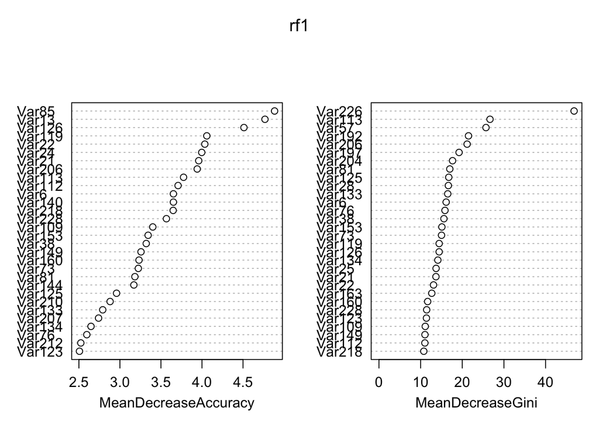

```r
varImpPlot(rf1)
```

The obove graph displays the mean decrease accuracy. It shows how removing one variable affects the overall model accuracy

Lets run the model on test data

```r
Prediction <- predict(rf1, test)
submit <- data.frame(ID=29955:34868, churn = Prediction)
```

There are two methods to overcome the skewed data, oversampling and undersampling.

# Oversampling

Load library rose

```r
library(ROSE)
over<-ovun.sample(as.factor(churn)~.,data=train,method="over",N=9280)$data
table(over$churn)
```

```
##
##    0    1
## 4640 4640
```

We can see that now due to oversampling we have an equal representation of 0’s and 1’s

```r
rf2<-randomForest(as.factor(churn)~.,data=over,importance=TRUE,ntree=30)
rf2
```

```
##
## Call:
##  randomForest(formula = as.factor(churn) ~ ., data = over, importance = TRUE,      ntree = 30)
##                Type of random forest: classification
##                      Number of trees: 30
## No. of variables tried at each split: 9
##
##         OOB estimate of  error rate: 0.48%
## Confusion matrix:
##      0    1 class.error
## 0 4595   45 0.009698276
## 1    0 4640 0.000000000
```

```r
#Prediction2<-predict(rf2,test)
#confusionMatrix(Prediction2,test$churn)
```

##### logistic regression

The glm() function is a genaralized linear model that includes logistic regression. The syntex of the glm() function is similar to lm(), except that we must pass in the argument family=binomial.

```r
#LR1 <- glm(churn~.,D[INR,],family=binomial(link = "logit"))
#summary(LR1)
#step(LR1) # stepwise selection by AIC
```

Since logistic regression takes longer time, lets try Lasso instead.

##### Lasso:

In statistics and machine learning, lasso (least absolute shrinkage and selection operator; also Lasso or LASSO) is a regression analysis method that performs both variable selection and regularization in order to enhance the prediction accuracy and interpretability of the statistical model it produces.

```r
library(glmnet)
x=model.matrix(churn~.,D)[,-1]
y=D$churn
train=sample(1:nrow(x),nrow(x)/2)
grid=10^seq(10,-2,length=100)
lasso.mod=glmnet(x[train,],y[train],alpha=1,lambda=grid,family="binomial")
```

here we have chosen to implement the function over a grid of values ranging from λ = 1010 to λ = 10−2,from lamda is equal to ten to the power of ten to ten to the power of minus two, essentially covering the full range of scenarios from the null model containing only the intercept, to the least squares fit.

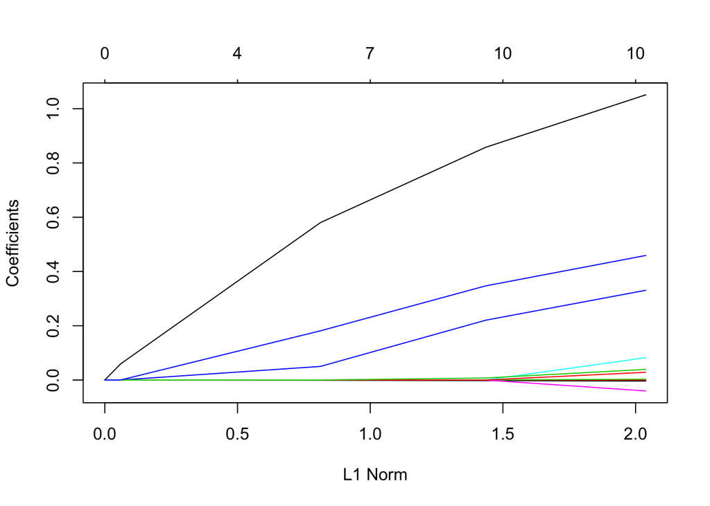

```r
plot(lasso.mod)
```

```r
set.seed(1)
cv.out=cv.glmnet(x[train,],y[train],alpha=1,family="binomial")
bestlam=cv.out$lambda.min
test=(-train)
y.test=y[test]
lasso.pred=predict(lasso.mod,s=bestlam,newx = x[test,],family="binomial")
out=glmnet(x,y,alpha = 1,lambda=grid,family="binomial")
lasso.coef=predict(out,type="coefficients",s=bestlam)
#lasso.coef

LR2 <- glm(churn~Var73+Var113+Var126+Var205+Var210+Var218+Var126NA,
           D[INR,],
           family=binomial(link = "logit"))

Prob <- predict(LR2, D[INS,], type="response") # fitted probability of churn
Pred <- (Prob > 0.5) + 0 # predicted churn (0/1)
#Pred
table(Pred, D[INS,"churn"])
```

```
##
## Pred     0     1
##    0 18560  1462
##    1    16     7
```

We got an error rate around 7%.

Conclusion:We have tried two different modeling methods , random forest and lasso. Both of them have an error rate of around 7%